# Risk Factor Analysis

## Outcome Variable

**Outcome Variable:** pers_wasted624

## Predictor Variables

**Intervention Variable:** ever_sstunted06

**Adjustment Set:**

- sex
- arm
- brthmon
- vagbrth
- single
- W_mage
- W_mhtcm
- W_mwtkg
- W_mbmi
- W_meducyrs
- W_feducyrs
- W_parity
- delta_brthmon
- delta_vagbrth
- delta_single
- delta_W_mage
- delta_W_mhtcm
- delta_W_mwtkg
- delta_W_mbmi
- delta_W_meducyrs
- delta_W_feducyrs
- delta_W_parity

## Stratifying Variables

The analysis was stratified on these variable(s):

- studyid
- country

## Data Summary

| studyid | country | ever_sstunted06 | pers_wasted624 | n_cell | n | outcome_variable |
| --- | --- | --- | --- | --- | --- | --- |
| CMC-V-BCS-2002 | INDIA | 0 | 0 | 260 | 370 | pers_wasted624 |
| CMC-V-BCS-2002 | INDIA | 0 | 1 | 16 | 370 | pers_wasted624 |
| CMC-V-BCS-2002 | INDIA | 1 | 0 | 82 | 370 | pers_wasted624 |
| CMC-V-BCS-2002 | INDIA | 1 | 1 | 12 | 370 | pers_wasted624 |
| CMIN | BANGLADESH | 0 | 0 | 181 | 252 | pers_wasted624 |
| CMIN | BANGLADESH | 0 | 1 | 12 | 252 | pers_wasted624 |
| CMIN | BANGLADESH | 1 | 0 | 46 | 252 | pers_wasted624 |
| CMIN | BANGLADESH | 1 | 1 | 13 | 252 | pers_wasted624 |
| COHORTS | GUATEMALA | 0 | 0 | 843 | 1023 | pers_wasted624 |
| COHORTS | GUATEMALA | 0 | 1 | 24 | 1023 | pers_wasted624 |
| COHORTS | GUATEMALA | 1 | 0 | 139 | 1023 | pers_wasted624 |
| COHORTS | GUATEMALA | 1 | 1 | 17 | 1023 | pers_wasted624 |
| COHORTS | INDIA | 0 | 0 | 5774 | 6893 | pers_wasted624 |
| COHORTS | INDIA | 0 | 1 | 648 | 6893 | pers_wasted624 |
| COHORTS | INDIA | 1 | 0 | 348 | 6893 | pers_wasted624 |
| COHORTS | INDIA | 1 | 1 | 123 | 6893 | pers_wasted624 |
| COHORTS | PHILIPPINES | 0 | 0 | 2411 | 2809 | pers_wasted624 |
| COHORTS | PHILIPPINES | 0 | 1 | 184 | 2809 | pers_wasted624 |
| COHORTS | PHILIPPINES | 1 | 0 | 172 | 2809 | pers_wasted624 |
| COHORTS | PHILIPPINES | 1 | 1 | 42 | 2809 | pers_wasted624 |
| CONTENT | PERU | 0 | 0 | 207 | 215 | pers_wasted624 |
| CONTENT | PERU | 0 | 1 | 0 | 215 | pers_wasted624 |
| CONTENT | PERU | 1 | 0 | 8 | 215 | pers_wasted624 |
| CONTENT | PERU | 1 | 1 | 0 | 215 | pers_wasted624 |
| EE | PAKISTAN | 0 | 0 | 188 | 373 | pers_wasted624 |
| EE | PAKISTAN | 0 | 1 | 24 | 373 | pers_wasted624 |
| EE | PAKISTAN | 1 | 0 | 136 | 373 | pers_wasted624 |
| EE | PAKISTAN | 1 | 1 | 25 | 373 | pers_wasted624 |
| GMS-Nepal | NEPAL | 0 | 0 | 454 | 590 | pers_wasted624 |
| GMS-Nepal | NEPAL | 0 | 1 | 88 | 590 | pers_wasted624 |

[output cut: 90 more lines]

The following strata were considered:

- studyid: CMC-V-BCS-2002, country: INDIA
- studyid: CMIN, country: BANGLADESH
- studyid: COHORTS, country: GUATEMALA
- studyid: COHORTS, country: INDIA
- studyid: COHORTS, country: PHILIPPINES
- studyid: CONTENT, country: PERU
- studyid: EE, country: PAKISTAN
- studyid: GMS-Nepal, country: NEPAL
- studyid: Guatemala BSC, country: GUATEMALA
- studyid: IRC, country: INDIA
- studyid: JiVitA-3, country: BANGLADESH
- studyid: JiVitA-4, country: BANGLADESH
- studyid: Keneba, country: GAMBIA
- studyid: LCNI-5, country: MALAWI
- studyid: MAL-ED, country: BANGLADESH
- studyid: MAL-ED, country: BRAZIL
- studyid: MAL-ED, country: INDIA
- studyid: MAL-ED, country: NEPAL
- studyid: MAL-ED, country: PERU
- studyid: MAL-ED, country: SOUTH AFRICA
- studyid: MAL-ED, country: TANZANIA, UNITED REPUBLIC OF
- studyid: NIH-Birth, country: BANGLADESH
- studyid: NIH-Crypto, country: BANGLADESH
- studyid: PROBIT, country: BELARUS
- studyid: PROVIDE, country: BANGLADESH
- studyid: ResPak, country: PAKISTAN
- studyid: SAS-CompFeed, country: INDIA
- studyid: SAS-FoodSuppl, country: INDIA
- studyid: TanzaniaChild2, country: TANZANIA, UNITED REPUBLIC OF
- studyid: ZVITAMBO, country: ZIMBABWE

### Dropped Strata

Some strata were dropped due to rare outcomes:

- studyid: CONTENT, country: PERU
- studyid: Guatemala BSC, country: GUATEMALA
- studyid: LCNI-5, country: MALAWI
- studyid: MAL-ED, country: BANGLADESH
- studyid: MAL-ED, country: BRAZIL
- studyid: MAL-ED, country: NEPAL
- studyid: MAL-ED, country: PERU
- studyid: MAL-ED, country: SOUTH AFRICA
- studyid: MAL-ED, country: TANZANIA, UNITED REPUBLIC OF
- studyid: PROBIT, country: BELARUS
- studyid: PROVIDE, country: BANGLADESH

## Methods Detail

We’re interested in the causal parameters $E[Y_a]$ for all values of $a \in \mathcal{A}$. These parameters represent the mean outcome if, possibly contrary to fact, we intervened to set all units to have $A=a$. Under the randomization and positivity assumptions, these are identified by the statistical parameters $\psi_a=E_W[E_{Y|A,W}(Y|A=a,W)]$. In addition, we’re interested in the mean of $Y$, $E[Y]$ under no intervention (the observed mean). We will estimate these parameters by using SuperLearner to fit the relevant likelihood factors – $E_{Y|A,W}(Y|A=a,W)$ and $p(A=a|W)$, and then updating our likelihood fit using a joint TMLE.

For unadjusted analyses ($W=\{\}$), initial likelihoods were estimated using Lrnr_glm to estimate the simple $E(Y|A)$ and Lrnr_mean to estimate $p(A)$. For adjusted analyses, a small library containing Lrnr_glmnet, Lrnr_xgboost, and Lrnr_mean was used.

Having estimated these parameters, we will then use the delta method to estimate relative risks and attributable risks relative to a prespecified baseline level of $A$.

# Results Detail

## Results Plots

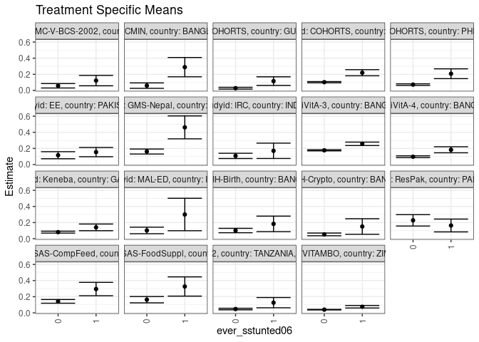

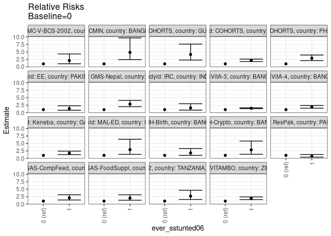

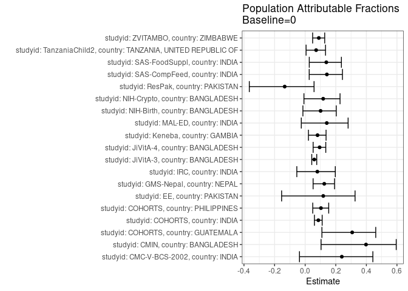

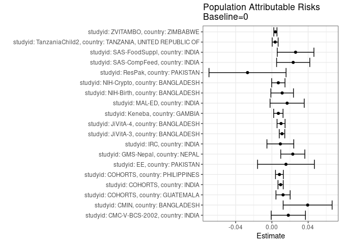

## Results Table

### Parameter: TSM

| studyid | country | intervention_level | baseline_level | estimate | ci_lower | ci_upper |
| --- | --- | --- | --- | --- | --- | --- |
| CMC-V-BCS-2002 | INDIA | 0 | NA | 0.0575491 | 0.0301472 | 0.0849509 |
| CMC-V-BCS-2002 | INDIA | 1 | NA | 0.1219907 | 0.0576063 | 0.1863751 |
| CMIN | BANGLADESH | 0 | NA | 0.0597495 | 0.0260609 | 0.0934381 |
| CMIN | BANGLADESH | 1 | NA | 0.2889653 | 0.1693823 | 0.4085482 |
| COHORTS | GUATEMALA | 0 | NA | 0.0277591 | 0.0167825 | 0.0387357 |
| COHORTS | GUATEMALA | 1 | NA | 0.1153655 | 0.0617650 | 0.1689660 |
| COHORTS | INDIA | 0 | NA | 0.1022196 | 0.0948042 | 0.1096349 |
| COHORTS | INDIA | 1 | NA | 0.2194990 | 0.1815112 | 0.2574869 |
| COHORTS | PHILIPPINES | 0 | NA | 0.0721507 | 0.0621588 | 0.0821427 |
| COHORTS | PHILIPPINES | 1 | NA | 0.2072389 | 0.1464450 | 0.2680328 |
| EE | PAKISTAN | 0 | NA | 0.1158406 | 0.0720722 | 0.1596091 |
| EE | PAKISTAN | 1 | NA | 0.1546176 | 0.0971137 | 0.2121215 |
| GMS-Nepal | NEPAL | 0 | NA | 0.1616991 | 0.1306433 | 0.1927549 |
| GMS-Nepal | NEPAL | 1 | NA | 0.4613173 | 0.3190950 | 0.6035397 |
| IRC | INDIA | 0 | NA | 0.1077393 | 0.0750887 | 0.1403898 |
| IRC | INDIA | 1 | NA | 0.1704749 | 0.0753815 | 0.2655683 |
| JiVitA-3 | BANGLADESH | 0 | NA | 0.1766133 | 0.1696012 | 0.1836254 |
| JiVitA-3 | BANGLADESH | 1 | NA | 0.2574926 | 0.2362871 | 0.2786982 |
| JiVitA-4 | BANGLADESH | 0 | NA | 0.0971652 | 0.0861359 | 0.1081945 |
| JiVitA-4 | BANGLADESH | 1 | NA | 0.1833789 | 0.1459866 | 0.2207711 |
| Keneba | GAMBIA | 0 | NA | 0.0811688 | 0.0693012 | 0.0930365 |
| Keneba | GAMBIA | 1 | NA | 0.1406020 | 0.0990614 | 0.1821426 |
| MAL-ED | INDIA | 0 | NA | 0.1023256 | 0.0617274 | 0.1429237 |
| MAL-ED | INDIA | 1 | NA | 0.3000000 | 0.0987348 | 0.5012652 |
| NIH-Birth | BANGLADESH | 0 | NA | 0.1012008 | 0.0740433 | 0.1283583 |
| NIH-Birth | BANGLADESH | 1 | NA | 0.1835130 | 0.0871265 | 0.2798995 |
| NIH-Crypto | BANGLADESH | 0 | NA | 0.0531758 | 0.0362619 | 0.0700896 |
| NIH-Crypto | BANGLADESH | 1 | NA | 0.1509434 | 0.0544976 | 0.2473892 |
| ResPak | PAKISTAN | 0 | NA | 0.2277563 | 0.1571956 | 0.2983170 |
| ResPak | PAKISTAN | 1 | NA | 0.1637231 | 0.0841803 | 0.2432659 |
| SAS-CompFeed | INDIA | 0 | NA | 0.1421906 | 0.1189852 | 0.1653961 |
| SAS-CompFeed | INDIA | 1 | NA | 0.2949694 | 0.2121194 | 0.3778194 |
| SAS-FoodSuppl | INDIA | 0 | NA | 0.1629267 | 0.1235635 | 0.2022899 |
| SAS-FoodSuppl | INDIA | 1 | NA | 0.3264105 | 0.2071602 | 0.4456609 |
| TanzaniaChild2 | TANZANIA, UNITED REPUBLIC OF | 0 | NA | 0.0469221 | 0.0374553 | 0.0563889 |
| TanzaniaChild2 | TANZANIA, UNITED REPUBLIC OF | 1 | NA | 0.1260155 | 0.0623910 | 0.1896400 |
| ZVITAMBO | ZIMBABWE | 0 | NA | 0.0393796 | 0.0354949 | 0.0432644 |
| ZVITAMBO | ZIMBABWE | 1 | NA | 0.0751854 | 0.0595606 | 0.0908101 |

### Parameter: E(Y)

| studyid | country | intervention_level | baseline_level | estimate | ci_lower | ci_upper |
| --- | --- | --- | --- | --- | --- | --- |
| CMC-V-BCS-2002 | INDIA | NA | NA | 0.0756757 | 0.0486905 | 0.1026609 |
| CMIN | BANGLADESH | NA | NA | 0.0992063 | 0.0622241 | 0.1361886 |
| COHORTS | GUATEMALA | NA | NA | 0.0400782 | 0.0280529 | 0.0521035 |
| COHORTS | INDIA | NA | NA | 0.1118526 | 0.1044114 | 0.1192938 |
| COHORTS | PHILIPPINES | NA | NA | 0.0804557 | 0.0703953 | 0.0905161 |
| EE | PAKISTAN | NA | NA | 0.1313673 | 0.0970401 | 0.1656945 |
| GMS-Nepal | NEPAL | NA | NA | 0.1847458 | 0.1534039 | 0.2160876 |
| IRC | INDIA | NA | NA | 0.1170732 | 0.0859146 | 0.1482317 |
| JiVitA-3 | BANGLADESH | NA | NA | 0.1877787 | 0.1812440 | 0.1943134 |
| JiVitA-4 | BANGLADESH | NA | NA | 0.1072855 | 0.0967458 | 0.1178252 |
| Keneba | GAMBIA | NA | NA | 0.0882993 | 0.0766987 | 0.0998998 |
| MAL-ED | INDIA | NA | NA | 0.1191489 | 0.0776405 | 0.1606574 |
| NIH-Birth | BANGLADESH | NA | NA | 0.1125461 | 0.0859151 | 0.1391771 |
| NIH-Crypto | BANGLADESH | NA | NA | 0.0602740 | 0.0429977 | 0.0775502 |
| ResPak | PAKISTAN | NA | NA | 0.2008547 | 0.1494120 | 0.2522974 |
| SAS-CompFeed | INDIA | NA | NA | 0.1657061 | 0.1471754 | 0.1842367 |
| SAS-FoodSuppl | INDIA | NA | NA | 0.1890547 | 0.1507312 | 0.2273783 |
| TanzaniaChild2 | TANZANIA, UNITED REPUBLIC OF | NA | NA | 0.0505451 | 0.0409848 | 0.0601054 |
| ZVITAMBO | ZIMBABWE | NA | NA | 0.0432327 | 0.0393972 | 0.0470683 |

### Parameter: RR

| studyid | country | intervention_level | baseline_level | estimate | ci_lower | ci_upper |
| --- | --- | --- | --- | --- | --- | --- |
| CMC-V-BCS-2002 | INDIA | 0 | 0 | 1.0000000 | 1.0000000 | 1.000000 |
| CMC-V-BCS-2002 | INDIA | 1 | 0 | 2.1197698 | 1.0382418 | 4.327917 |
| CMIN | BANGLADESH | 0 | 0 | 1.0000000 | 1.0000000 | 1.000000 |
| CMIN | BANGLADESH | 1 | 0 | 4.8362818 | 2.4117743 | 9.698097 |
| COHORTS | GUATEMALA | 0 | 0 | 1.0000000 | 1.0000000 | 1.000000 |
| COHORTS | GUATEMALA | 1 | 0 | 4.1559516 | 2.2619795 | 7.635760 |
| COHORTS | INDIA | 0 | 0 | 1.0000000 | 1.0000000 | 1.000000 |
| COHORTS | INDIA | 1 | 0 | 2.1473286 | 1.7803837 | 2.589902 |
| COHORTS | PHILIPPINES | 0 | 0 | 1.0000000 | 1.0000000 | 1.000000 |
| COHORTS | PHILIPPINES | 1 | 0 | 2.8723060 | 2.0768706 | 3.972391 |
| EE | PAKISTAN | 0 | 0 | 1.0000000 | 1.0000000 | 1.000000 |
| EE | PAKISTAN | 1 | 0 | 1.3347438 | 0.7839884 | 2.272407 |
| GMS-Nepal | NEPAL | 0 | 0 | 1.0000000 | 1.0000000 | 1.000000 |
| GMS-Nepal | NEPAL | 1 | 0 | 2.8529366 | 1.9833000 | 4.103891 |
| IRC | INDIA | 0 | 0 | 1.0000000 | 1.0000000 | 1.000000 |
| IRC | INDIA | 1 | 0 | 1.5822915 | 0.8385522 | 2.985677 |
| JiVitA-3 | BANGLADESH | 0 | 0 | 1.0000000 | 1.0000000 | 1.000000 |
| JiVitA-3 | BANGLADESH | 1 | 0 | 1.4579459 | 1.3314944 | 1.596406 |
| JiVitA-4 | BANGLADESH | 0 | 0 | 1.0000000 | 1.0000000 | 1.000000 |
| JiVitA-4 | BANGLADESH | 1 | 0 | 1.8872898 | 1.4918503 | 2.387547 |
| Keneba | GAMBIA | 0 | 0 | 1.0000000 | 1.0000000 | 1.000000 |
| Keneba | GAMBIA | 1 | 0 | 1.7322168 | 1.2464998 | 2.407201 |
| MAL-ED | INDIA | 0 | 0 | 1.0000000 | 1.0000000 | 1.000000 |
| MAL-ED | INDIA | 1 | 0 | 2.9318182 | 1.3447391 | 6.391989 |
| NIH-Birth | BANGLADESH | 0 | 0 | 1.0000000 | 1.0000000 | 1.000000 |
| NIH-Birth | BANGLADESH | 1 | 0 | 1.8133557 | 1.0051453 | 3.271426 |
| NIH-Crypto | BANGLADESH | 0 | 0 | 1.0000000 | 1.0000000 | 1.000000 |
| NIH-Crypto | BANGLADESH | 1 | 0 | 2.8385744 | 1.3903512 | 5.795302 |
| ResPak | PAKISTAN | 0 | 0 | 1.0000000 | 1.0000000 | 1.000000 |
| ResPak | PAKISTAN | 1 | 0 | 0.7188521 | 0.4035845 | 1.280397 |
| SAS-CompFeed | INDIA | 0 | 0 | 1.0000000 | 1.0000000 | 1.000000 |
| SAS-CompFeed | INDIA | 1 | 0 | 2.0744642 | 1.3865985 | 3.103567 |
| SAS-FoodSuppl | INDIA | 0 | 0 | 1.0000000 | 1.0000000 | 1.000000 |
| SAS-FoodSuppl | INDIA | 1 | 0 | 2.0034194 | 1.2926922 | 3.104907 |
| TanzaniaChild2 | TANZANIA, UNITED REPUBLIC OF | 0 | 0 | 1.0000000 | 1.0000000 | 1.000000 |
| TanzaniaChild2 | TANZANIA, UNITED REPUBLIC OF | 1 | 0 | 2.6856312 | 1.5588584 | 4.626857 |
| ZVITAMBO | ZIMBABWE | 0 | 0 | 1.0000000 | 1.0000000 | 1.000000 |
| ZVITAMBO | ZIMBABWE | 1 | 0 | 1.9092456 | 1.5171862 | 2.402618 |

### Parameter: PAR

| studyid | country | intervention_level | baseline_level | estimate | ci_lower | ci_upper |
| --- | --- | --- | --- | --- | --- | --- |
| CMC-V-BCS-2002 | INDIA | 0 | NA | 0.0181266 | -0.0007816 | 0.0370348 |
| CMIN | BANGLADESH | 0 | NA | 0.0394569 | 0.0124435 | 0.0664703 |
| COHORTS | GUATEMALA | 0 | NA | 0.0123191 | 0.0044924 | 0.0201458 |
| COHORTS | INDIA | 0 | NA | 0.0096330 | 0.0067405 | 0.0125255 |
| COHORTS | PHILIPPINES | 0 | NA | 0.0083050 | 0.0039957 | 0.0126143 |
| EE | PAKISTAN | 0 | NA | 0.0155267 | -0.0158315 | 0.0468848 |
| GMS-Nepal | NEPAL | 0 | NA | 0.0230466 | 0.0097652 | 0.0363281 |
| IRC | INDIA | 0 | NA | 0.0093339 | -0.0054717 | 0.0241396 |
| JiVitA-3 | BANGLADESH | 0 | NA | 0.0111654 | 0.0081150 | 0.0142159 |
| JiVitA-4 | BANGLADESH | 0 | NA | 0.0101203 | 0.0057031 | 0.0145376 |
| Keneba | GAMBIA | 0 | NA | 0.0071304 | 0.0019716 | 0.0122892 |
| MAL-ED | INDIA | 0 | NA | 0.0168234 | -0.0020257 | 0.0356724 |
| NIH-Birth | BANGLADESH | 0 | NA | 0.0113453 | -0.0011220 | 0.0238127 |
| NIH-Crypto | BANGLADESH | 0 | NA | 0.0070982 | -0.0002455 | 0.0144419 |
| ResPak | PAKISTAN | 0 | NA | -0.0269016 | -0.0694279 | 0.0156246 |
| SAS-CompFeed | INDIA | 0 | NA | 0.0235154 | 0.0052086 | 0.0418222 |
| SAS-FoodSuppl | INDIA | 0 | NA | 0.0261280 | 0.0058896 | 0.0463664 |
| TanzaniaChild2 | TANZANIA, UNITED REPUBLIC OF | 0 | NA | 0.0036230 | 0.0003493 | 0.0068967 |
| ZVITAMBO | ZIMBABWE | 0 | NA | 0.0038531 | 0.0021144 | 0.0055918 |

### Parameter: PAF

| studyid | country | intervention_level | baseline_level | estimate | ci_lower | ci_upper |
| --- | --- | --- | --- | --- | --- | --- |
| CMC-V-BCS-2002 | INDIA | 0 | NA | 0.2395304 | -0.0372563 | 0.4424579 |
| CMIN | BANGLADESH | 0 | NA | 0.3977253 | 0.1040134 | 0.5951560 |
| COHORTS | GUATEMALA | 0 | NA | 0.3073766 | 0.1094650 | 0.4613046 |
| COHORTS | INDIA | 0 | NA | 0.0861226 | 0.0604438 | 0.1110995 |
| COHORTS | PHILIPPINES | 0 | NA | 0.1032242 | 0.0495508 | 0.1538665 |
| EE | PAKISTAN | 0 | NA | 0.1181927 | -0.1539343 | 0.3261452 |
| GMS-Nepal | NEPAL | 0 | NA | 0.1247479 | 0.0518249 | 0.1920625 |
| IRC | INDIA | 0 | NA | 0.0797272 | -0.0546049 | 0.1969486 |
| JiVitA-3 | BANGLADESH | 0 | NA | 0.0594607 | 0.0430907 | 0.0755506 |
| JiVitA-4 | BANGLADESH | 0 | NA | 0.0943308 | 0.0520490 | 0.1347267 |
| Keneba | GAMBIA | 0 | NA | 0.0807529 | 0.0213337 | 0.1365646 |
| MAL-ED | INDIA | 0 | NA | 0.1411960 | -0.0253403 | 0.2806834 |
| NIH-Birth | BANGLADESH | 0 | NA | 0.1008062 | -0.0148034 | 0.2032451 |
| NIH-Crypto | BANGLADESH | 0 | NA | 0.1177655 | -0.0080550 | 0.2278818 |
| ResPak | PAKISTAN | 0 | NA | -0.1339357 | -0.3651123 | 0.0580920 |
| SAS-CompFeed | INDIA | 0 | NA | 0.1419104 | 0.0264554 | 0.2436733 |
| SAS-FoodSuppl | INDIA | 0 | NA | 0.1382034 | 0.0268180 | 0.2368403 |
| TanzaniaChild2 | TANZANIA, UNITED REPUBLIC OF | 0 | NA | 0.0716783 | 0.0059920 | 0.1330239 |
| ZVITAMBO | ZIMBABWE | 0 | NA | 0.0891247 | 0.0488395 | 0.1277036 |